# TP 3: Classification with genetic markers

OUAZZANI CHAHDI Mohammed

CHERKAOUI Ayoub

KERZAZI Achraf

### Part 1

```r
set.seed(0)
NAm2 = read.table("NAm2.txt", header=TRUE)

cont <- function(x){
if(x %in% c('Canada'))
cont <- 'NorthAmerica'
else if(x %in% c('Guatemala', 'Mexico', 'Panama', 'CostaRica'))
cont<-'CentralAmerica'
else
cont<-'SouthAmerica'
return(factor(cont))
}
contID<-sapply(as.character(NAm2[,4]),FUN=cont)
```

### Part 2

#### (a).

```r
library("nnet")
NAcont <- cbind(contID=contID, NAm2[,-(1:8)])
NAcont[,1] <- factor(NAcont[,1])
```

```r
multinomModel <- multinom(NAcont[,1]~., NAcont)
```

```
## Error in nnet.default(X, Y, w, mask = mask, size = 0, skip = TRUE, softmax = TRUE, : too many (17139) weights
```

We notice that the computations of the weights of the model cannot be done, and that is because the number of parameters is too big, making it impossible for the gradient descent algorithm used to calculate the weights and biases to converge.

```r
multinomModel <- multinom(NAcont[,1]~., NAcont, MaxNWts = 18000, maxit=200)
```

#### (b).

```r
pcaNAcont <- prcomp(NAcont[,-1],center=T, scale=F)
pcaData <- as.data.frame(pcaNAcont$x[,1:331])
multinomModelPca <- multinom(NAcont[,1]~. , data=pcaData)
```

The maximum number of principal components to use is $331$ so the algorithm converges

```r
prediction_multinom <- predict(multinomModelPca, newdata=pcaData)
confMatrix <- table(prediction_multinom, NAcont[,1])
cat("Mean classification error:", 1 - sum(diag(confMatrix))/sum(confMatrix))
```

```
## Mean classification error: 0
```

Our model classifies perfectly the data. However we are confident that we are overfiting, and that is because we use the whole dataset for training and validation, and use the maximum number of principal components to build the model. We need then to the cross validation to avoid these problem

#### (c).

```r
set.seed(5)
K <- 10

vec <- c(1:nrow(NAcont))
index_split <- split(sample(vec), 1:10)
lower_bounds <- c()
upper_bounds <- c()

mce_training <- c()
mce_validation <- c()
#loop for PCA's
for (i in seq(from = 10, to = 331, by = 10)){
  #loop for folds
  mce_training_i <- c() #mean classification error for the iteration i
  mce_validation_i <- c() #mean classification error for the iteration i
  for (k in 1:K){
    valid_ik <- as.numeric(index_split[[k]]) #validation set
    pcaData_ik <- as.data.frame(pcaNAcont$x[,1:i])

    multinomModelPca_ik <- multinom(NAcont[-valid_ik,1]~. , data = pcaData_ik[-valid_ik,], trace=FALSE)

    prediction_valid_ik <- predict(multinomModelPca_ik, newdata=pcaData_ik[valid_ik,])
    prediction_training_ik <- predict(multinomModelPca_ik)

    conf_matrix_valid_ik <- table(prediction_valid_ik, NAcont[valid_ik,1])
    conf_matrix_training_ik <- table(prediction_training_ik, NAcont[-valid_ik,1])

    mce_training_i <- c(mce_training_i, 1 - sum(diag(conf_matrix_training_ik))/sum(conf_matrix_training_ik))
    mce_validation_i <- c(mce_validation_i, 1 - sum(diag(conf_matrix_valid_ik))/sum(conf_matrix_valid_ik))
  }

  mce_training <- c(mce_training, mean(mce_training_i))
  mce_validation <- c(mce_validation, mean(mce_validation_i))

  #Calculating confidence bounds for the classification error
  # Calculate the standard error of the mean
  se <- sd(mce_validation_i) / sqrt(length(mce_validation_i))

  # Calculate the t-value for a 95% confidence interval with n-1 degrees of freedom
  df <- length(mce_validation_i) - 1
  t_value <- qt(0.975, df)

  # Calculate the upper and lower bounds of the confidence interval
  upper_bounds <- c(upper_bounds, mean(mce_validation_i) + t_value * se)
  lower_bounds <- c(lower_bounds, mean(mce_validation_i) - t_value * se)

}
```

```r
first_guess <- seq(from=10, to=331, by=10)[which.min(mce_validation)]
cat("Our first guess for the optimal number of principle components is ", first_guess)
```

```
## Our first guess for the optimal number of principle components is  150
```

The initial guess of the optimal number of principle components is $\hat{P} = 150$, we then refine our guess between $\hat{P}-9$ and $\hat{P}+9$ and provide a confidence interval for the guess

```r
set.seed(5)
mce_validation_refined <- c()
#loop for PCA's
for (i in seq(from = 150-9, to = 150+9, by = 1)){
  #loop for folds
  mce_training_i <- c() #mean classification error for the iteration i
  mce_validation_i <- c() #mean classification error for the iteration i
  for (k in 1:K){
    valid_ik <- as.numeric(index_split[[k]]) #validation set
    pcaData_ik <- as.data.frame(pcaNAcont$x[,1:i])

    multinomModelPca_ik <- multinom(NAcont[-valid_ik,1]~. , data = pcaData_ik[-valid_ik,], trace=FALSE)

    prediction_valid_ik <- predict(multinomModelPca_ik, newdata=pcaData_ik[valid_ik,])

    conf_matrix_valid_ik <- table(prediction_valid_ik, NAcont[valid_ik,1])

    mce_validation_i <- c(mce_validation_i, 1 - sum(diag(conf_matrix_valid_ik))/sum(conf_matrix_valid_ik))
  }
  mce_validation_refined <- c(mce_validation_refined, mean(mce_validation_i))
}

x <- seq(from = 150-9, to = 150+9, by = 1)
optim <- x[which.min(mce_validation_refined)]
cat("The optimal number of principle components is thus: ", optim)
```

```
## The optimal number of principle components is thus:  148
```

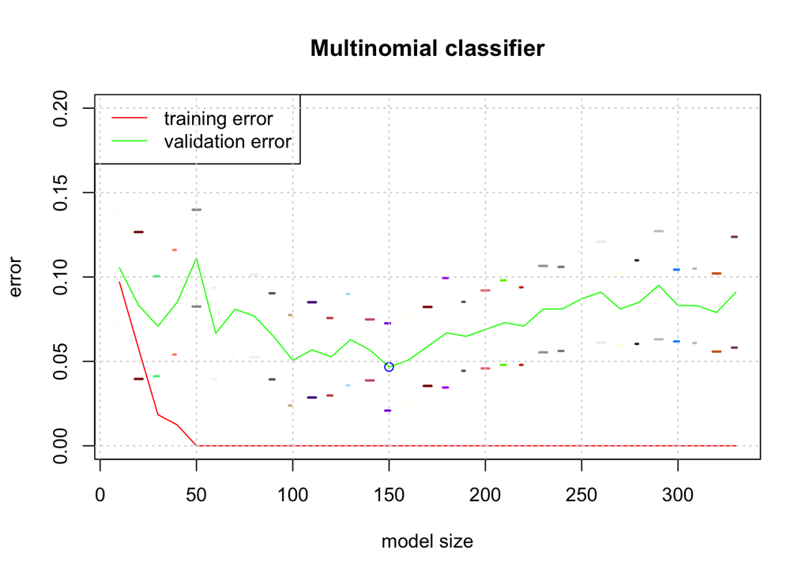

```r
x <- seq(from=10, to=331, by=10)
plot(x, mce_training, type = "l", col = "red", xlab = "model size", ylab = "error", ylim = c(0, 0.2), main = "Multinomial classifier" )
lines(x, mce_validation, col = "green")
legend("topleft", legend = c("training error", "validation error"), col = c("red", "green"), lty = 1)
for (i in seq(from = 10, to=331, by = 10)){
  col = sample(colors())
  segments(i - 2, lower_bounds[i/10], i + 2 ,lower_bounds[i/10], i,lwd=2, col = col)
  segments(i - 2, upper_bounds[i/10], i + 2 ,upper_bounds[i/10], i,lwd=2, col = col)
}
points(150, mce_validation[150/10], col="blue")
grid()
```

#### (d).

```r
pcaData <- as.data.frame(pcaNAcont$x[,1:148])
multinomModelPca <- multinom(NAcont[,1]~. , data=pcaData)
prediction_multinom <- predict(multinomModelPca, newdata=pcaData)
confMatrix <- table(prediction_multinom, NAcont[,1])
cat("Mean classification error:", 1 - sum(diag(confMatrix))/sum(confMatrix))
```

```
## Mean classification error: 0
```

The preceding question shows that the validation better is optimal for $148$ principal components, so using this number would be more accurate. In addition, the multinomial model only needs to learn $298$ parameters instead of $664$, which makes it converge more rapidly. Therefore, we have better results now because we have decreased the possibility of overfiting and reduced the computational complexity of the model.

### Part 3

```r
library(MASS, class)
pcaData <- as.data.frame(pcaNAcont$x[,1:491])
ldaModelPca <- lda(NAcont[,1]~. , data=pcaData)
```

```r
prediction_lda <- predict(ldaModelPca, newdata=pcaData)
confMatrix <- table(prediction_multinom, NAcont[,1])
cat("Mean classification error:", 1 - sum(diag(confMatrix))/sum(confMatrix))
```

```
## Mean classification error: 0
```

### Part 4

#### (a).

We compute the maximal number of principal components

```r
library(naivebayes)
pcaData <- as.data.frame(pcaNAcont$x)
nBayesModelPca <- naive_bayes(NAcont[,1]~. , data=pcaData)
prediction_nBayes <- predict(nBayesModelPca, newdata=pcaData)
confMatrix <- table(prediction_nBayes, NAcont[,1])
cat("Mean classification error for the naive bayes classifier with all the principle components:", 1 - sum(diag(confMatrix))/sum(confMatrix))
```

```
## Mean classification error for the naive bayes classifier with all the principle components: 0.2712551
```

We can use all the principle components because the model assumes the the classes are considered independent and we choose a law to model them. It doesn’t require a lot of calculations like the multinom model. However the error is not as good as the multinom model. This gives us an idea about our data, the hypothesis of independance that we did for our classes is probably too strong.

We procede with a 10-fold cross validation

```r
cross_validation_classification <- function(classification_model, from, to, by, predict_train=TRUE) {
  K <- 10
  vec <- c(1:nrow(NAcont))
  index_split <- split(sample(vec), 1:10)

  lower_bounds <- c()
  upper_bounds <- c()

  mce_training <- c()
  mce_validation <- c()

  # Loop for PCA's
  for (i in seq(from = from, to = to, by = by)){
    # Loop for folds
    mce_training_i <- c() # Mean classification error for the iteration i
    mce_validation_i <- c() # Mean classification error for the iteration i
    for (k in 1:K){
      valid_ik <- as.numeric(index_split[[k]]) # Validation set
      pcaData_ik <- as.data.frame(pcaNAcont$x[,1:i])

      multinomModelPca_ik <- classification_model(NAcont[-valid_ik,1] ~ . , data = pcaData_ik[-valid_ik,], trace=FALSE)

      prediction_valid_ik <- predict(multinomModelPca_ik, newdata=pcaData_ik[valid_ik,])
      if (predict_train){prediction_training_ik <- predict(multinomModelPca_ik, newdata=pcaData_ik[-valid_ik,])}

      conf_matrix_valid_ik <- table(prediction_valid_ik, NAcont[valid_ik,1])
      if (predict_train){conf_matrix_training_ik <- table(prediction_training_ik, NAcont[-valid_ik,1])}
      if (predict_train){ mce_training_i <- c(mce_training_i, 1 - sum(diag(conf_matrix_training_ik))/sum(conf_matrix_training_ik))}
      mce_validation_i <- c(mce_validation_i, 1 - sum(diag(conf_matrix_valid_ik))/sum(conf_matrix_valid_ik))
    }

    if(predict_train){mce_training <- c(mce_training, mean(mce_training_i))}
    mce_validation <- c(mce_validation, mean(mce_validation_i))

    # Calculating confidence bounds for the classification error
    # Calculate the standard error of the mean
    se <- sd(mce_validation_i) / sqrt(length(mce_validation_i))

    # Calculate the t-value for a 95% confidence interval with n-1 degrees of freedom
    df <- length(mce_validation_i) - 1
    t_value <- qt(0.975, df)

    # Calculate the upper and lower bounds of the confidence interval
    upper_bounds <- c(upper_bounds, mean(mce_validation_i) + t_value * se)
    lower_bounds <- c(lower_bounds, mean(mce_validation_i) - t_value * se)
  }

  # Return the metrics as a list
  metrics <- list(mce_training = mce_training,
                  mce_validation = mce_validation,
                  upper_bounds = upper_bounds,
                  lower_bounds = lower_bounds)
  return(metrics)
}
```

```r
nBayes_metrics <- cross_validation_classification(naive_bayes, from=10, to=494, by=10)
first_guess <- seq(from=10, to=494, by=10)[which.min(nBayes_metrics$mce_validation)]
cat("Our first guess for the optimal number of principle components is ", first_guess)
```

```
## Our first guess for the optimal number of principle components is  50
```

The 10-step cross validation provides us with the first guess for the number of principle components: 50

We refine it:

```r
set.seed(5)
nBayes_metrics_refined <- cross_validation_classification(naive_bayes, from=first_guess-9, to=first_guess+9, by=1, predict_train = FALSE)
x <- seq(from = first_guess-9, to = first_guess+9, by = 1)
optim <- x[which.min(nBayes_metrics_refined$mce_validation)]
cat("The optimal number of principle components for the naive bayes classifier is thus: ", optim)
```

```
## The optimal number of principle components for the naive bayes classifier is thus:  51
```

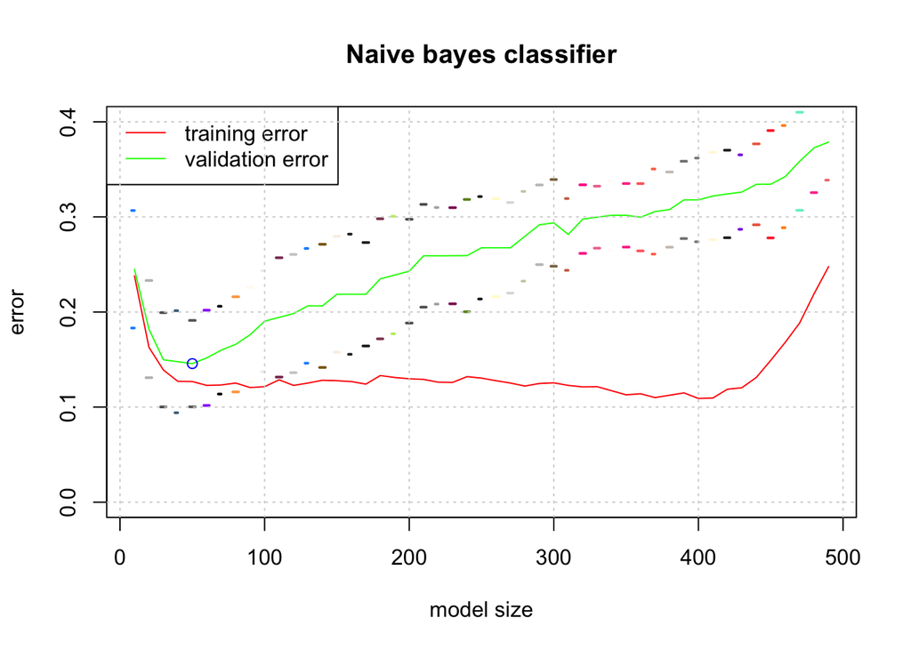

```r
x <- seq(from=10, to=494, by=10)
plot(x, nBayes_metrics$mce_training, type = "l", col = "red", xlab = "model size", ylab = "error", ylim = c(0, 0.4), main = "Naive bayes classifier" )
lines(x, nBayes_metrics$mce_validation, col = "green")
legend("topleft", legend = c("training error", "validation error"), col = c("red", "green"), lty = 1)
for (i in seq(from = 10, to=494, by = 10)){
  col = sample(colors())
  segments(i - 2, nBayes_metrics$lower_bounds[i/10], i + 2 ,nBayes_metrics$lower_bounds[i/10], i,lwd=2, col = col)
  segments(i - 2, nBayes_metrics$upper_bounds[i/10], i + 2 ,nBayes_metrics$upper_bounds[i/10], i,lwd=2, col = col)
}
points(first_guess, (nBayes_metrics$mce_validation)[first_guess/10], col="blue")
grid()
```